# Getting Started with RII

## What RII is, and why this package exists

The Relative Importance Index (RII) ranks a set of factors, causes or criteria that respondents have rated on a Likert scale. For item $j$:

$$RII_j = \frac{\sum W_j}{A \times
N_j}$$

where $\sum W_j$ is the sum of the weights (raw Likert scores) given to item $j$ by all respondents, $A$ is the highest possible weight (5 on a 5-point scale), and $N_j$ is the number of respondents who rated it. RII always falls between 0 and 1, which makes items directly comparable and rankable — this is why it is so widely used in environmental, construction and social-science surveys.

Most researchers compute this in a spreadsheet: one `SUMPRODUCT` and one `COUNT` formula per item, copied down a column, then sorted by hand. The **RII** package does the same calculation from R, with automatic ranking and a ready-made chart, as a first step towards analysing survey data in R instead of Excel.

## The example data

The package ships a worked Nigerian example: 150 construction professionals across seven states rating ten perceived causes of building collapse on a 5-point scale (1 = Not significant, 5 = Extremely significant).

```r
library(RII)
data(building_collapse_nigeria)
head(building_collapse_nigeria[, 1:6])
```

```
#>   RespondentID        Profession State YearsExperience SubstandardMaterials
#> 1            1 Quantity Surveyor Lagos               7                    5
#> 2            2           Builder Lagos               8                    5
#> 3            3    Civil Engineer   Edo              11                    4
#> 4            4    Civil Engineer   Oyo               9                    5
#> 5            5           Builder Kwara               9                    4
#> 6            6    Civil Engineer Kwara              12                    5
#>   PoorSupervision
#> 1               5
#> 2               5
#> 3               3
#> 4               4
#> 5               5
#> 6               5
```

## Ranking items from raw responses

If you have one row per respondent and one column per item — the usual shape for data exported from Google Forms, KoboToolbox or a survey platform — pass those columns straight to `rii_table()`:

```r
items <- building_collapse_nigeria[, 5:14]
tbl <- rii_table(items)
tbl
```

```
#> Relative Importance Index table (scale 1-5)
#> ----------------------------------------
#>                         Item   N  Mean    SD   RII Rank        Band
#>         SubstandardMaterials 150 4.720 0.569 0.944    1        High
#>    NonComplianceBuildingCode 150 4.647 0.657 0.929    2        High
#>              PoorWorkmanship 150 4.633 0.727 0.927    3        High
#>              PoorSupervision 150 4.607 0.713 0.921    4        High
#>          UnqualifiedArtisans 150 4.493 0.841 0.899    5        High
#>    CorruptionApprovalProcess 150 4.480 0.865 0.896    6        High
#>       StructuralDesignErrors 150 4.140 1.232 0.828    7        High
#>  InadequateSoilInvestigation 150 4.027 1.152 0.805    8        High
#>                  Overloading 150 3.727 1.263 0.745    9 High-Medium
#>            LackOfMaintenance 150 3.353 1.391 0.671   10 High-Medium
```

The result is sorted by RII automatically, and each item is placed into one of the five importance bands used in the literature (Low, Medium-Low, Medium, High-Medium, High) via `classify_rii()` internally.

`summary()` gives a quick narrative reading of the table:

```r
summary(tbl)
```

```
#> Items ranked          : 10
#> Top-ranked item        : SubstandardMaterials (RII = 0.944)
#> RII range              : 0.671 to 0.944
#> Mean RII across items  : 0.857
#>
#> Items per importance band:
#>
#>        High High-Medium      Medium  Medium-Low         Low
#>           8           2           0           0           0
```

## A one-line entry point for messy real-world survey data

Real exports usually mix Likert items with demographic/ID columns (gender, age, marital status…) that are numerically just as “Likert-like” as a real item — a gender column coded 1/2 looks no different to R than a real 2-point item. Typing out 30+ item column names by hand is tedious, so `items = "auto"` detects them from the common short-code naming convention (`OJ1`, `PJ6`, `JS1i`, …) instead:

```r
set.seed(1)
raw_survey <- data.frame(
  `S/N` = 1:40, GENDER = sample(1:2, 40, TRUE),
  MARITAL = sample(1:3, 40, TRUE),
  OJ1 = sample(1:5, 40, TRUE), OJ2 = sample(1:5, 40, TRUE),
  PJ6 = sample(1:5, 40, TRUE), JS1i = sample(1:5, 40, TRUE),
  check.names = FALSE
)

# review the guess first
detect_likert_items(raw_survey)
```

```
#> 4 of 7 columns suggested as Likert items
#> ----------------------------------------
#>   Column N_Unique Min Max Pct_NA Suggested
#>      S/N       40   1  40      0     FALSE
#>   GENDER        2   1   2      0     FALSE
#>  MARITAL        3   1   3      0     FALSE
#>      OJ1        5   1   5      0      TRUE
#>      OJ2        5   1   5      0      TRUE
#>      PJ6        5   1   5      0      TRUE
#>     JS1i        5   1   5      0      TRUE
#>                                             Reason
#>              name matches a demographic/ID keyword
#>              name matches a demographic/ID keyword
#>              name matches a demographic/ID keyword
#>  name matches item-code pattern (e.g. OJ1, JS2iii)
#>  name matches item-code pattern (e.g. OJ1, JS2iii)
#>  name matches item-code pattern (e.g. OJ1, JS2iii)
#>  name matches item-code pattern (e.g. OJ1, JS2iii)
```

```r
# or just let rii_table() use it directly
rii_table(raw_survey, items = "auto")
```

```
#> rii_table(items = "auto"): using 4 detected item column(s): OJ1, OJ2, PJ6, JS1i
#> Excluded 3 column(s): S/N, GENDER, MARITAL
#> Run detect_likert_items(data) yourself to review or adjust this.
#> Relative Importance Index table (scale 1-5)
#> ----------------------------------------
#>  Item  N  Mean    SD   RII Rank        Band
#>   OJ1 40 3.125 1.399 0.625    1 High-Medium
#>   PJ6 40 3.100 1.598 0.620    2 High-Medium
#>  JS1i 40 3.100 1.499 0.620    3 High-Medium
#>   OJ2 40 2.750 1.316 0.550    4      Medium
```

## Multiple constructs/sections in one questionnaire

A longer questionnaire often has several distinct sections — e.g. “Road Surface Quality” (columns 4-10) and “Maintenance Practices” (columns 11-13) — that should usually be ranked **separately**, since mixing two different constructs into one RII table isn’t generally meaningful. `items` accepts a numeric column range for exactly this, so you can call `rii_table()` (or `read_rii_csv()`/`read_rii_excel()`/`read_rii_spss()`) once per section:

```r
d <- read.csv("road_infra_survey_raw.csv")   # read the whole file once

road_quality <- rii_table(d, items = 4:10)   # Section 1
maintenance  <- rii_table(d, items = 11:13)  # Section 2
```

Note that the column range has to be a real R argument (`items = 11:17`), not text appended to the file path — `read_rii_csv("file.csv[, 11:17]", ...)` won’t work, since indexing isn’t part of a file name.

## Text Likert labels (“Strongly Agree”, “Disagree”, …)

Many surveys (Google Forms exports especially) record responses as text rather than numbers. `recode_likert()` converts them, and can auto-detect which columns to convert:

```r
text_survey <- data.frame(
  Gender = sample(c("Male", "Female"), 30, TRUE),
  Q1 = sample(c("Strongly disagree", "Disagree", "Neutral", "Agree", "Strongly agree"), 30, TRUE),
  Q2 = sample(c("Strongly disagree", "Disagree", "Neutral", "Agree", "Strongly agree"), 30, TRUE)
)

# review which columns it would recode, and using which scale
detect_text_likert_items(text_survey)
```

```
#> 2 of 3 columns match a known Likert wording
#> ----------------------------------------
#>  Column N_Unique                            Sample_Values Matched_Scale
#>  Gender        2                             Male, Female          <NA>
#>      Q1        5 Agree, Disagree, Strongly agree, Neutral    agreement5
#>      Q2        5 Strongly agree, Neutral, Disagree, Agree    agreement5
#>  Suggested                                   Reason
#>      FALSE values don't match a known scale wording
#>       TRUE      values match the 'agreement5' scale
#>       TRUE      values match the 'agreement5' scale
```

```r
# recode, then rank — items = "auto" picks up exactly the recoded columns
text_survey2 <- recode_likert(text_survey)
```

```
#> recode_likert(): auto-detected and recoded 2 column(s):
#>   - Q1 (agreement5)
#>   - Q2 (agreement5)
```

```r
rii_table(text_survey2, items = "auto")
```

```
#> rii_table(items = "auto"): using the 2 column(s) already recoded by recode_likert(): Q1, Q2
#> Relative Importance Index table (scale 1-5)
#> ----------------------------------------
#>  Item  N  Mean    SD   RII Rank        Band
#>    Q1 30 3.033 1.426 0.607    1 High-Medium
#>    Q2 30 2.800 1.448 0.560    2      Medium
```

Built-in wordings cover agreement (with or without “Neutral”/“Undecided”), frequency, satisfaction, importance and extent scales. For anything else, pass your own mapping: `recode_likert(d, cols = "Q1", mapping = c("no" = 1, "maybe" = 2, "yes" = 3))`.

## Ranking items from a frequency table

Many spreadsheet RII templates don’t keep raw respondent-level data — only a count of how many respondents chose each scale point for each item. `rii_table_freq()` works directly from that layout:

```r
freq <- data.frame(
  Factor = c("Poor supervision", "Use of substandard materials"),
  SD = c(2, 1), D = c(5, 4), N = c(10, 12), A = c(38, 40), SA = c(95, 93)
)
rii_table_freq(freq, item_col = "Factor")
```

```
#> Relative Importance Index table (scale 1-5)
#> ----------------------------------------
#>                          Item   N  Mean    SD   RII Rank Band
#>  Use of substandard materials 150 4.467 0.808 0.893    1 High
#>              Poor supervision 150 4.460 0.864 0.892    2 High
```

## Reading straight from an Excel workbook

If your data already lives in an `.xlsx` file — either layout — you can skip the import step entirely:

```r
raw_path <- system.file("extdata", "rii_raw_example.xlsx", package = "RII")
read_rii_excel(raw_path, layout = "raw",
                items = c("SubstandardMaterials", "PoorSupervision",
                          "InadequateSoilInvestigation", "PoorWorkmanship"))
```

```
#> Relative Importance Index table (scale 1-5)
#> ----------------------------------------
#>                         Item  N  Mean    SD   RII Rank Band
#>         SubstandardMaterials 40 4.725 0.640 0.945    1 High
#>              PoorSupervision 40 4.675 0.526 0.935    2 High
#>              PoorWorkmanship 40 4.650 0.580 0.930    3 High
#>  InadequateSoilInvestigation 40 4.100 1.215 0.820    4 High
```

## Writing results back to Excel

If you’d rather hand someone a spreadsheet than an R object, write the ranked table straight to `.xlsx`. Importance bands are colour-coded the way many published RII tables shade them, and the chart is embedded in the same sheet by default:

```r
out <- tempfile(fileext = ".xlsx")
write_rii_excel(tbl, out)
```

## Plotting the ranking

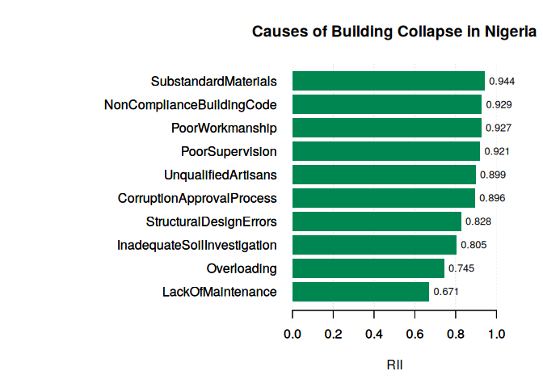

```r
plot(tbl, main = "Causes of Building Collapse in Nigeria")
```

Use `top_n` to show only the highest-ranked items, and `col` to change the bar colour for a different context:

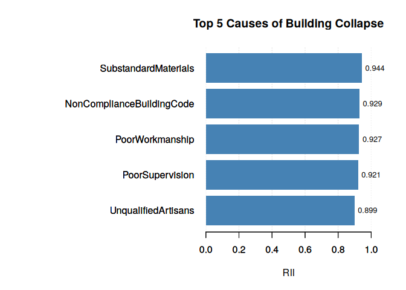

```r
plot(tbl, top_n = 5, col = "steelblue",
     main = "Top 5 Causes of Building Collapse")
```

## Single-item building blocks

If you want to build something custom, `rii_raw()` and `rii_freq()` compute the same statistics for one item at a time:

```r
rii_raw(items$PoorSupervision)
```

```
#>           n         sum        mean          sd         rii
#> 150.0000000 691.0000000   4.6066667   0.7132181   0.9213333
```

```r
rii_freq(c(2, 5, 10, 38, 95))
```

```
#>           n         sum        mean          sd         rii
#> 150.0000000 669.0000000   4.4600000   0.8641246   0.8920000
```

## A non-construction example, on a different scale

RII is not specific to construction, and neither is this package. The second bundled dataset, `csa_adoption_barriers_nigeria`, is a survey of smallholder farmers rating barriers to climate-smart agriculture adoption — on a **4-point** scale rather than 5-point, to show that `scale_max` (and `scale_min`, for a 0-based or otherwise shifted scale) adapts to whatever instrument was actually used:

```r
data(csa_adoption_barriers_nigeria)
csa_items <- csa_adoption_barriers_nigeria[, 6:15]
csa_tbl <- rii_table(csa_items, scale_max = 4)
csa_tbl
```

```
#> Relative Importance Index table (scale 1-4)
#> ----------------------------------------
#>                          Item   N  Mean    SD   RII Rank        Band
#>      HighCostOfImprovedInputs 175 3.651 0.642 0.913    1        High
#>          LackOfAccessToCredit 175 3.520 0.808 0.880    2        High
#>      LimitedExtensionServices 175 3.520 0.787 0.880    3        High
#>  UnpredictableWeatherPatterns 175 3.383 0.814 0.846    4        High
#>       LackOfGovernmentSupport 175 3.303 0.913 0.826    5        High
#>     InadequateIrrigationInfra 175 3.246 0.948 0.811    6        High
#>      LackOfTechnicalKnowledge 175 3.240 0.941 0.810    7        High
#>          LandTenureInsecurity 175 3.017 1.058 0.754    8 High-Medium
#>            LackOfMarketAccess 175 2.989 1.109 0.747    9 High-Medium
#>             LowLiteracyLevels 175 2.377 1.020 0.594   10      Medium
```

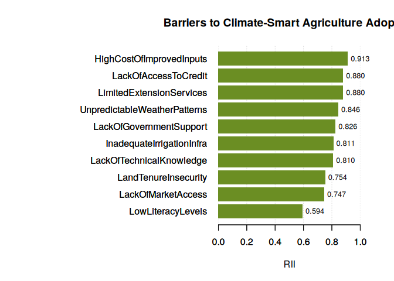

```r
plot(csa_tbl, main = "Barriers to Climate-Smart Agriculture Adoption",
     col = "#6B8E23")
```